# Risk Factor Analysis

## Outcome Variable

**Outcome Variable:** haz

## Predictor Variables

**Intervention Variable:** mwtkg

**Adjustment Set:**

- arm
- W_mage
- W_fage
- meducyrs
- feducyrs
- single
- brthmon
- delta_W_mage
- delta_W_fage
- delta_meducyrs
- delta_feducyrs
- delta_single
- delta_brthmon

## Stratifying Variables

The analysis was stratified on these variable(s):

- agecat
- studyid
- country

## Data Summary

| agecat | studyid | country | mwtkg | n_cell | n |
| --- | --- | --- | --- | --- | --- |
| Birth | ki0047075b-MAL-ED | BANGLADESH | >=58 kg | 47 | 246 |
| Birth | ki0047075b-MAL-ED | BANGLADESH | <52 kg | 156 | 246 |
| Birth | ki0047075b-MAL-ED | BANGLADESH | [52-58) kg | 43 | 246 |
| Birth | ki0047075b-MAL-ED | BRAZIL | >=58 kg | 121 | 184 |
| Birth | ki0047075b-MAL-ED | BRAZIL | <52 kg | 33 | 184 |
| Birth | ki0047075b-MAL-ED | BRAZIL | [52-58) kg | 30 | 184 |
| Birth | ki0047075b-MAL-ED | INDIA | >=58 kg | 36 | 198 |
| Birth | ki0047075b-MAL-ED | INDIA | <52 kg | 123 | 198 |
| Birth | ki0047075b-MAL-ED | INDIA | [52-58) kg | 39 | 198 |
| Birth | ki0047075b-MAL-ED | NEPAL | >=58 kg | 57 | 172 |
| Birth | ki0047075b-MAL-ED | NEPAL | <52 kg | 52 | 172 |
| Birth | ki0047075b-MAL-ED | NEPAL | [52-58) kg | 63 | 172 |
| Birth | ki0047075b-MAL-ED | PERU | >=58 kg | 99 | 276 |
| Birth | ki0047075b-MAL-ED | PERU | <52 kg | 107 | 276 |
| Birth | ki0047075b-MAL-ED | PERU | [52-58) kg | 70 | 276 |
| Birth | ki0047075b-MAL-ED | SOUTH AFRICA | >=58 kg | 166 | 228 |
| Birth | ki0047075b-MAL-ED | SOUTH AFRICA | <52 kg | 23 | 228 |
| Birth | ki0047075b-MAL-ED | SOUTH AFRICA | [52-58) kg | 39 | 228 |
| Birth | ki0047075b-MAL-ED | TANZANIA, UNITED REPUBLIC OF | >=58 kg | 52 | 121 |
| Birth | ki0047075b-MAL-ED | TANZANIA, UNITED REPUBLIC OF | <52 kg | 40 | 121 |
| Birth | ki0047075b-MAL-ED | TANZANIA, UNITED REPUBLIC OF | [52-58) kg | 29 | 121 |
| Birth | ki1000304b-SAS-CompFeed | INDIA | >=58 kg | 14 | 182 |
| Birth | ki1000304b-SAS-CompFeed | INDIA | <52 kg | 141 | 182 |
| Birth | ki1000304b-SAS-CompFeed | INDIA | [52-58) kg | 27 | 182 |
| Birth | ki1017093-NIH-Birth | BANGLADESH | >=58 kg | 2 | 28 |
| Birth | ki1017093-NIH-Birth | BANGLADESH | <52 kg | 23 | 28 |
| Birth | ki1017093-NIH-Birth | BANGLADESH | [52-58) kg | 3 | 28 |
| Birth | ki1017093c-NIH-Crypto | BANGLADESH | >=58 kg | 4 | 27 |
| Birth | ki1017093c-NIH-Crypto | BANGLADESH | <52 kg | 20 | 27 |
| Birth | ki1017093c-NIH-Crypto | BANGLADESH | [52-58) kg | 3 | 27 |

[output cut: 93 more lines]

The following strata were considered:

- agecat: 24 months, studyid: ki0047075b-MAL-ED, country: BANGLADESH
- agecat: 24 months, studyid: ki0047075b-MAL-ED, country: BRAZIL
- agecat: 24 months, studyid: ki0047075b-MAL-ED, country: INDIA
- agecat: 24 months, studyid: ki0047075b-MAL-ED, country: NEPAL
- agecat: 24 months, studyid: ki0047075b-MAL-ED, country: PERU
- agecat: 24 months, studyid: ki0047075b-MAL-ED, country: SOUTH AFRICA
- agecat: 24 months, studyid: ki0047075b-MAL-ED, country: TANZANIA, UNITED REPUBLIC OF
- agecat: 24 months, studyid: ki1017093-NIH-Birth, country: BANGLADESH
- agecat: 24 months, studyid: ki1017093b-PROVIDE, country: BANGLADESH
- agecat: 24 months, studyid: ki1017093c-NIH-Crypto, country: BANGLADESH
- agecat: 24 months, studyid: ki1066203-TanzaniaChild2, country: TANZANIA, UNITED REPUBLIC OF
- agecat: 24 months, studyid: ki1119695-PROBIT, country: BELARUS
- agecat: 24 months, studyid: ki1126311-ZVITAMBO, country: ZIMBABWE
- agecat: 24 months, studyid: ki1148112-LCNI-5, country: MALAWI
- agecat: 6 months, studyid: ki0047075b-MAL-ED, country: BANGLADESH
- agecat: 6 months, studyid: ki0047075b-MAL-ED, country: BRAZIL
- agecat: 6 months, studyid: ki0047075b-MAL-ED, country: INDIA
- agecat: 6 months, studyid: ki0047075b-MAL-ED, country: NEPAL
- agecat: 6 months, studyid: ki0047075b-MAL-ED, country: PERU
- agecat: 6 months, studyid: ki0047075b-MAL-ED, country: SOUTH AFRICA
- agecat: 6 months, studyid: ki0047075b-MAL-ED, country: TANZANIA, UNITED REPUBLIC OF
- agecat: 6 months, studyid: ki1000304b-SAS-CompFeed, country: INDIA
- agecat: 6 months, studyid: ki1017093-NIH-Birth, country: BANGLADESH
- agecat: 6 months, studyid: ki1017093b-PROVIDE, country: BANGLADESH
- agecat: 6 months, studyid: ki1017093c-NIH-Crypto, country: BANGLADESH
- agecat: 6 months, studyid: ki1066203-TanzaniaChild2, country: TANZANIA, UNITED REPUBLIC OF
- agecat: 6 months, studyid: ki1119695-PROBIT, country: BELARUS
- agecat: 6 months, studyid: ki1126311-ZVITAMBO, country: ZIMBABWE
- agecat: 6 months, studyid: ki1148112-LCNI-5, country: MALAWI
- agecat: Birth, studyid: ki0047075b-MAL-ED, country: BANGLADESH
- agecat: Birth, studyid: ki0047075b-MAL-ED, country: BRAZIL
- agecat: Birth, studyid: ki0047075b-MAL-ED, country: INDIA
- agecat: Birth, studyid: ki0047075b-MAL-ED, country: NEPAL
- agecat: Birth, studyid: ki0047075b-MAL-ED, country: PERU
- agecat: Birth, studyid: ki0047075b-MAL-ED, country: SOUTH AFRICA
- agecat: Birth, studyid: ki0047075b-MAL-ED, country: TANZANIA, UNITED REPUBLIC OF
- agecat: Birth, studyid: ki1000304b-SAS-CompFeed, country: INDIA
- agecat: Birth, studyid: ki1017093-NIH-Birth, country: BANGLADESH
- agecat: Birth, studyid: ki1017093c-NIH-Crypto, country: BANGLADESH
- agecat: Birth, studyid: ki1119695-PROBIT, country: BELARUS
- agecat: Birth, studyid: ki1126311-ZVITAMBO, country: ZIMBABWE

### Dropped Strata

Some strata were dropped due to rare outcomes:

- agecat: Birth, studyid: ki1017093-NIH-Birth, country: BANGLADESH
- agecat: Birth, studyid: ki1017093c-NIH-Crypto, country: BANGLADESH
- agecat: 24 months, studyid: ki1066203-TanzaniaChild2, country: TANZANIA, UNITED REPUBLIC OF

## Methods Detail

We’re interested in the causal parameters $E[Y_a]$ for all values of $a \in \mathcal{A}$. These parameters represent the mean outcome if, possibly contrary to fact, we intervened to set all units to have $A=a$. Under the randomization and positivity assumptions, these are identified by the statistical parameters $\psi_a=E_W[E_{Y|A,W}(Y|A=a,W)]$. In addition, we’re interested in the mean of $Y$, $E[Y]$ under no intervention (the observed mean). We will estimate these parameters by using SuperLearner to fit the relevant likelihood factors – $E_{Y|A,W}(Y|A=a,W)$ and $p(A=a|W)$, and then updating our likelihood fit using a joint TMLE.

For unadjusted analyses ($W=\{\}$), initial likelihoods were estimated using Lrnr_glm to estimate the simple $E(Y|A)$ and Lrnr_mean to estimate $p(A)$. For adjusted analyses, a small library containing Lrnr_glmnet, Lrnr_xgboost, and Lrnr_mean was used.

Having estimated these parameters, we will then use the delta method to estimate relative risks and attributable risks relative to a prespecified baseline level of $A$.

# Results Detail

## Results Plots

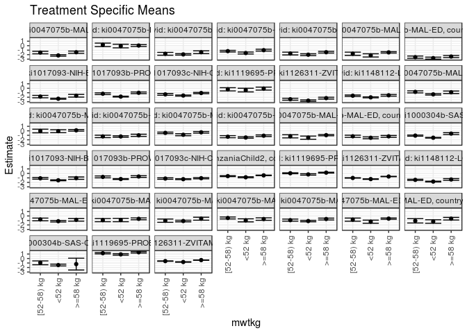

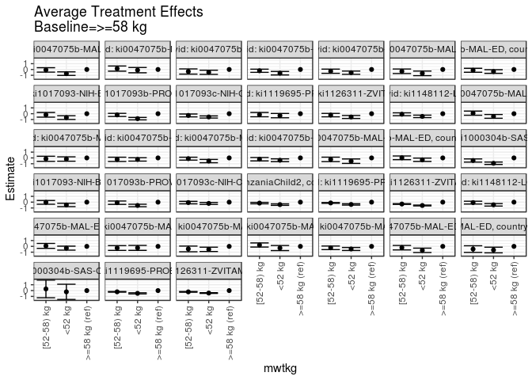

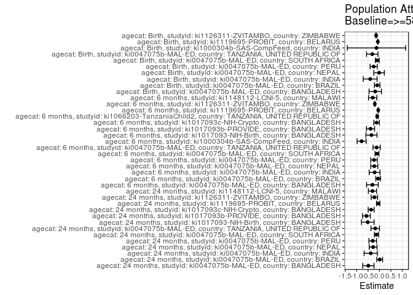

## Results Table

### Parameter: TSM

| agecat | studyid | country | intervention_level | baseline_level | estimate | ci_lower | ci_upper |
| --- | --- | --- | --- | --- | --- | --- | --- |
| Birth | ki0047075b-MAL-ED | BANGLADESH | >=58 kg | NA | -0.8621853 | -1.1595031 | -0.5648674 |
| Birth | ki0047075b-MAL-ED | BANGLADESH | <52 kg | NA | -1.1709525 | -1.3428406 | -0.9990643 |
| Birth | ki0047075b-MAL-ED | BANGLADESH | [52-58) kg | NA | -0.7813310 | -1.0842278 | -0.4784343 |
| Birth | ki0047075b-MAL-ED | BRAZIL | >=58 kg | NA | -0.6416076 | -0.8451818 | -0.4380333 |
| Birth | ki0047075b-MAL-ED | BRAZIL | <52 kg | NA | -0.9041117 | -1.2795542 | -0.5286692 |
| Birth | ki0047075b-MAL-ED | BRAZIL | [52-58) kg | NA | -0.9228647 | -1.2799415 | -0.5657879 |
| Birth | ki0047075b-MAL-ED | INDIA | >=58 kg | NA | -0.6135250 | -0.9434308 | -0.2836192 |
| Birth | ki0047075b-MAL-ED | INDIA | <52 kg | NA | -1.1284941 | -1.3060573 | -0.9509309 |
| Birth | ki0047075b-MAL-ED | INDIA | [52-58) kg | NA | -1.0521525 | -1.4150483 | -0.6892568 |
| Birth | ki0047075b-MAL-ED | NEPAL | >=58 kg | NA | -0.6895356 | -0.9670164 | -0.4120549 |
| Birth | ki0047075b-MAL-ED | NEPAL | <52 kg | NA | -0.9777014 | -1.3150884 | -0.6403144 |
| Birth | ki0047075b-MAL-ED | NEPAL | [52-58) kg | NA | -0.4550622 | -0.6742097 | -0.2359147 |
| Birth | ki0047075b-MAL-ED | PERU | >=58 kg | NA | -0.6848902 | -0.8869502 | -0.4828302 |
| Birth | ki0047075b-MAL-ED | PERU | <52 kg | NA | -1.1350543 | -1.2942030 | -0.9759056 |
| Birth | ki0047075b-MAL-ED | PERU | [52-58) kg | NA | -0.9358808 | -1.1665719 | -0.7051897 |
| Birth | ki0047075b-MAL-ED | SOUTH AFRICA | >=58 kg | NA | -0.5972964 | -0.7474762 | -0.4471167 |
| Birth | ki0047075b-MAL-ED | SOUTH AFRICA | <52 kg | NA | -1.2786552 | -1.6254958 | -0.9318146 |
| Birth | ki0047075b-MAL-ED | SOUTH AFRICA | [52-58) kg | NA | -0.8253763 | -1.1787701 | -0.4719826 |
| Birth | ki0047075b-MAL-ED | TANZANIA, UNITED REPUBLIC OF | >=58 kg | NA | -0.6115570 | -0.8977976 | -0.3253163 |
| Birth | ki0047075b-MAL-ED | TANZANIA, UNITED REPUBLIC OF | <52 kg | NA | -1.2390505 | -1.6277924 | -0.8503085 |
| Birth | ki0047075b-MAL-ED | TANZANIA, UNITED REPUBLIC OF | [52-58) kg | NA | -1.0803120 | -1.5713786 | -0.5892453 |
| Birth | ki1000304b-SAS-CompFeed | INDIA | >=58 kg | NA | -1.2424079 | -2.5613322 | 0.0765165 |
| Birth | ki1000304b-SAS-CompFeed | INDIA | <52 kg | NA | -1.4583317 | -1.6610679 | -1.2555954 |
| Birth | ki1000304b-SAS-CompFeed | INDIA | [52-58) kg | NA | -0.9587133 | -1.3853382 | -0.5320884 |
| Birth | ki1119695-PROBIT | BELARUS | >=58 kg | NA | 1.3976860 | 1.2364537 | 1.5589184 |
| Birth | ki1119695-PROBIT | BELARUS | <52 kg | NA | 0.9247236 | 0.7594810 | 1.0899663 |
| Birth | ki1119695-PROBIT | BELARUS | [52-58) kg | NA | 1.1849587 | 1.0342208 | 1.3356966 |
| Birth | ki1126311-ZVITAMBO | ZIMBABWE | >=58 kg | NA | -0.3509531 | -0.3827646 | -0.3191416 |
| Birth | ki1126311-ZVITAMBO | ZIMBABWE | <52 kg | NA | -0.7756850 | -0.8251398 | -0.7262301 |
| Birth | ki1126311-ZVITAMBO | ZIMBABWE | [52-58) kg | NA | -0.5721463 | -0.6181725 | -0.5261201 |

[output cut: 84 more lines]

### Parameter: E(Y)

| agecat | studyid | country | intervention_level | baseline_level | estimate | ci_lower | ci_upper |
| --- | --- | --- | --- | --- | --- | --- | --- |
| Birth | ki0047075b-MAL-ED | BANGLADESH | NA | NA | -1.0455285 | -1.1715695 | -0.9194875 |
| Birth | ki0047075b-MAL-ED | BRAZIL | NA | NA | -0.7397283 | -0.8996215 | -0.5798350 |
| Birth | ki0047075b-MAL-ED | INDIA | NA | NA | -1.0200505 | -1.1624932 | -0.8776078 |
| Birth | ki0047075b-MAL-ED | NEPAL | NA | NA | -0.7052907 | -0.8627483 | -0.5478331 |
| Birth | ki0047075b-MAL-ED | PERU | NA | NA | -0.9386232 | -1.0507144 | -0.8265319 |
| Birth | ki0047075b-MAL-ED | SOUTH AFRICA | NA | NA | -0.6921930 | -0.8218578 | -0.5625282 |
| Birth | ki0047075b-MAL-ED | TANZANIA, UNITED REPUBLIC OF | NA | NA | -0.9267769 | -1.1425813 | -0.7109724 |
| Birth | ki1000304b-SAS-CompFeed | INDIA | NA | NA | -1.3716484 | -1.5489439 | -1.1943528 |
| Birth | ki1119695-PROBIT | BELARUS | NA | NA | 1.3264008 | 1.1675653 | 1.4852363 |
| Birth | ki1126311-ZVITAMBO | ZIMBABWE | NA | NA | -0.4974449 | -0.5203958 | -0.4744941 |
| 6 months | ki0047075b-MAL-ED | BANGLADESH | NA | NA | -1.2056777 | -1.3231497 | -1.0882058 |
| 6 months | ki0047075b-MAL-ED | BRAZIL | NA | NA | 0.0532131 | -0.0914567 | 0.1978830 |
| 6 months | ki0047075b-MAL-ED | INDIA | NA | NA | -1.2148369 | -1.3332371 | -1.0964367 |
| 6 months | ki0047075b-MAL-ED | NEPAL | NA | NA | -0.5610593 | -0.6737915 | -0.4483272 |
| 6 months | ki0047075b-MAL-ED | PERU | NA | NA | -1.3272488 | -1.4359649 | -1.2185326 |
| 6 months | ki0047075b-MAL-ED | SOUTH AFRICA | NA | NA | -1.0728012 | -1.2026830 | -0.9429194 |
| 6 months | ki0047075b-MAL-ED | TANZANIA, UNITED REPUBLIC OF | NA | NA | -1.3601215 | -1.4821830 | -1.2380600 |
| 6 months | ki1000304b-SAS-CompFeed | INDIA | NA | NA | -1.4006917 | -1.4821813 | -1.3192022 |
| 6 months | ki1017093-NIH-Birth | BANGLADESH | NA | NA | -1.4073821 | -1.4960598 | -1.3187043 |
| 6 months | ki1017093b-PROVIDE | BANGLADESH | NA | NA | -1.0848568 | -1.1613109 | -1.0084028 |
| 6 months | ki1017093c-NIH-Crypto | BANGLADESH | NA | NA | -1.1986783 | -1.2700937 | -1.1272630 |
| 6 months | ki1066203-TanzaniaChild2 | TANZANIA, UNITED REPUBLIC OF | NA | NA | -0.5424765 | -0.5918460 | -0.4931071 |
| 6 months | ki1119695-PROBIT | BELARUS | NA | NA | 0.1143882 | 0.0212298 | 0.2075466 |
| 6 months | ki1126311-ZVITAMBO | ZIMBABWE | NA | NA | -0.8994195 | -0.9257684 | -0.8730707 |
| 6 months | ki1148112-LCNI-5 | MALAWI | NA | NA | -1.6584707 | -1.7281551 | -1.5887863 |
| 24 months | ki0047075b-MAL-ED | BANGLADESH | NA | NA | -1.9431132 | -2.0691678 | -1.8170586 |
| 24 months | ki0047075b-MAL-ED | BRAZIL | NA | NA | 0.0418452 | -0.1263708 | 0.2100613 |
| 24 months | ki0047075b-MAL-ED | INDIA | NA | NA | -1.8439159 | -1.9704751 | -1.7173568 |
| 24 months | ki0047075b-MAL-ED | NEPAL | NA | NA | -1.2752193 | -1.3954783 | -1.1549603 |
| 24 months | ki0047075b-MAL-ED | PERU | NA | NA | -1.7500995 | -1.8705474 | -1.6296516 |
| 24 months | ki0047075b-MAL-ED | SOUTH AFRICA | NA | NA | -1.6220299 | -1.7590593 | -1.4850005 |
| 24 months | ki0047075b-MAL-ED | TANZANIA, UNITED REPUBLIC OF | NA | NA | -2.6058879 | -2.7403043 | -2.4714714 |
| 24 months | ki1017093-NIH-Birth | BANGLADESH | NA | NA | -2.1807945 | -2.2835902 | -2.0779987 |
| 24 months | ki1017093b-PROVIDE | BANGLADESH | NA | NA | -1.5839236 | -1.6672059 | -1.5006413 |
| 24 months | ki1017093c-NIH-Crypto | BANGLADESH | NA | NA | -1.4295331 | -1.5127726 | -1.3462935 |
| 24 months | ki1119695-PROBIT | BELARUS | NA | NA | -0.1312742 | -0.4286264 | 0.1660780 |
| 24 months | ki1126311-ZVITAMBO | ZIMBABWE | NA | NA | -2.4241972 | -2.5387692 | -2.3096253 |
| 24 months | ki1148112-LCNI-5 | MALAWI | NA | NA | -1.8747405 | -1.9558403 | -1.7936407 |

### Parameter: ATE

| agecat | studyid | country | intervention_level | baseline_level | estimate | ci_lower | ci_upper |
| --- | --- | --- | --- | --- | --- | --- | --- |
| Birth | ki0047075b-MAL-ED | BANGLADESH | >=58 kg | >=58 kg | 0.0000000 | 0.0000000 | 0.0000000 |
| Birth | ki0047075b-MAL-ED | BANGLADESH | <52 kg | >=58 kg | -0.3087672 | -0.6529522 | 0.0354177 |
| Birth | ki0047075b-MAL-ED | BANGLADESH | [52-58) kg | >=58 kg | 0.0808542 | -0.3440186 | 0.5057270 |
| Birth | ki0047075b-MAL-ED | BRAZIL | >=58 kg | >=58 kg | 0.0000000 | 0.0000000 | 0.0000000 |
| Birth | ki0047075b-MAL-ED | BRAZIL | <52 kg | >=58 kg | -0.2625042 | -0.6901273 | 0.1651190 |
| Birth | ki0047075b-MAL-ED | BRAZIL | [52-58) kg | >=58 kg | -0.2812571 | -0.6939719 | 0.1314577 |
| Birth | ki0047075b-MAL-ED | INDIA | >=58 kg | >=58 kg | 0.0000000 | 0.0000000 | 0.0000000 |
| Birth | ki0047075b-MAL-ED | INDIA | <52 kg | >=58 kg | -0.5149691 | -0.8887935 | -0.1411447 |
| Birth | ki0047075b-MAL-ED | INDIA | [52-58) kg | >=58 kg | -0.4386276 | -0.9288731 | 0.0516180 |
| Birth | ki0047075b-MAL-ED | NEPAL | >=58 kg | >=58 kg | 0.0000000 | 0.0000000 | 0.0000000 |
| Birth | ki0047075b-MAL-ED | NEPAL | <52 kg | >=58 kg | -0.2881658 | -0.7268247 | 0.1504932 |
| Birth | ki0047075b-MAL-ED | NEPAL | [52-58) kg | >=58 kg | 0.2344734 | -0.1200061 | 0.5889530 |
| Birth | ki0047075b-MAL-ED | PERU | >=58 kg | >=58 kg | 0.0000000 | 0.0000000 | 0.0000000 |
| Birth | ki0047075b-MAL-ED | PERU | <52 kg | >=58 kg | -0.4501641 | -0.7084797 | -0.1918484 |
| Birth | ki0047075b-MAL-ED | PERU | [52-58) kg | >=58 kg | -0.2509906 | -0.5585436 | 0.0565625 |
| Birth | ki0047075b-MAL-ED | SOUTH AFRICA | >=58 kg | >=58 kg | 0.0000000 | 0.0000000 | 0.0000000 |
| Birth | ki0047075b-MAL-ED | SOUTH AFRICA | <52 kg | >=58 kg | -0.6813588 | -1.0604708 | -0.3022467 |
| Birth | ki0047075b-MAL-ED | SOUTH AFRICA | [52-58) kg | >=58 kg | -0.2280799 | -0.6118493 | 0.1556895 |
| Birth | ki0047075b-MAL-ED | TANZANIA, UNITED REPUBLIC OF | >=58 kg | >=58 kg | 0.0000000 | 0.0000000 | 0.0000000 |
| Birth | ki0047075b-MAL-ED | TANZANIA, UNITED REPUBLIC OF | <52 kg | >=58 kg | -0.6274935 | -1.1149011 | -0.1400859 |
| Birth | ki0047075b-MAL-ED | TANZANIA, UNITED REPUBLIC OF | [52-58) kg | >=58 kg | -0.4687550 | -1.0402553 | 0.1027452 |
| Birth | ki1000304b-SAS-CompFeed | INDIA | >=58 kg | >=58 kg | 0.0000000 | 0.0000000 | 0.0000000 |
| Birth | ki1000304b-SAS-CompFeed | INDIA | <52 kg | >=58 kg | -0.2159238 | -1.5241154 | 1.0922678 |
| Birth | ki1000304b-SAS-CompFeed | INDIA | [52-58) kg | >=58 kg | 0.2836946 | -1.2339188 | 1.8013079 |
| Birth | ki1119695-PROBIT | BELARUS | >=58 kg | >=58 kg | 0.0000000 | 0.0000000 | 0.0000000 |
| Birth | ki1119695-PROBIT | BELARUS | <52 kg | >=58 kg | -0.4729624 | -0.5697189 | -0.3762059 |
| Birth | ki1119695-PROBIT | BELARUS | [52-58) kg | >=58 kg | -0.2127274 | -0.2659620 | -0.1594927 |
| Birth | ki1126311-ZVITAMBO | ZIMBABWE | >=58 kg | >=58 kg | 0.0000000 | 0.0000000 | 0.0000000 |
| Birth | ki1126311-ZVITAMBO | ZIMBABWE | <52 kg | >=58 kg | -0.4247319 | -0.4835616 | -0.3659021 |
| Birth | ki1126311-ZVITAMBO | ZIMBABWE | [52-58) kg | >=58 kg | -0.2211932 | -0.2771482 | -0.1652382 |

[output cut: 84 more lines]

### Parameter: PAR

| agecat | studyid | country | intervention_level | baseline_level | estimate | ci_lower | ci_upper |
| --- | --- | --- | --- | --- | --- | --- | --- |
| Birth | ki0047075b-MAL-ED | BANGLADESH | >=58 kg | NA | -0.1833432 | -0.4551521 | 0.0884657 |
| Birth | ki0047075b-MAL-ED | BRAZIL | >=58 kg | NA | -0.0981207 | -0.2186498 | 0.0224084 |
| Birth | ki0047075b-MAL-ED | INDIA | >=58 kg | NA | -0.4065255 | -0.7093378 | -0.1037132 |
| Birth | ki0047075b-MAL-ED | NEPAL | >=58 kg | NA | -0.0157551 | -0.2464072 | 0.2148970 |
| Birth | ki0047075b-MAL-ED | PERU | >=58 kg | NA | -0.2537330 | -0.4120119 | -0.0954540 |
| Birth | ki0047075b-MAL-ED | SOUTH AFRICA | >=58 kg | NA | -0.0948966 | -0.1797081 | -0.0100851 |
| Birth | ki0047075b-MAL-ED | TANZANIA, UNITED REPUBLIC OF | >=58 kg | NA | -0.3152199 | -0.5668466 | -0.0635932 |
| Birth | ki1000304b-SAS-CompFeed | INDIA | >=58 kg | NA | -0.1292405 | -1.4057037 | 1.1472228 |
| Birth | ki1119695-PROBIT | BELARUS | >=58 kg | NA | -0.0712852 | -0.0822922 | -0.0602783 |
| Birth | ki1126311-ZVITAMBO | ZIMBABWE | >=58 kg | NA | -0.1464918 | -0.1689643 | -0.1240194 |
| 6 months | ki0047075b-MAL-ED | BANGLADESH | >=58 kg | NA | -0.3090853 | -0.5648632 | -0.0533074 |
| 6 months | ki0047075b-MAL-ED | BRAZIL | >=58 kg | NA | -0.0560208 | -0.1603706 | 0.0483290 |
| 6 months | ki0047075b-MAL-ED | INDIA | >=58 kg | NA | -0.2123982 | -0.4485509 | 0.0237546 |
| 6 months | ki0047075b-MAL-ED | NEPAL | >=58 kg | NA | -0.2262894 | -0.3807020 | -0.0718767 |
| 6 months | ki0047075b-MAL-ED | PERU | >=58 kg | NA | -0.2374188 | -0.3810991 | -0.0937386 |
| 6 months | ki0047075b-MAL-ED | SOUTH AFRICA | >=58 kg | NA | -0.1076091 | -0.1930661 | -0.0221520 |
| 6 months | ki0047075b-MAL-ED | TANZANIA, UNITED REPUBLIC OF | >=58 kg | NA | -0.1245953 | -0.2835251 | 0.0343346 |
| 6 months | ki1000304b-SAS-CompFeed | INDIA | >=58 kg | NA | -0.7801463 | -0.9779666 | -0.5823260 |
| 6 months | ki1017093-NIH-Birth | BANGLADESH | >=58 kg | NA | -0.3499047 | -0.5937673 | -0.1060421 |
| 6 months | ki1017093b-PROVIDE | BANGLADESH | >=58 kg | NA | -0.3919419 | -0.5699103 | -0.2139736 |
| 6 months | ki1017093c-NIH-Crypto | BANGLADESH | >=58 kg | NA | -0.1252516 | -0.2454695 | -0.0050336 |
| 6 months | ki1066203-TanzaniaChild2 | TANZANIA, UNITED REPUBLIC OF | >=58 kg | NA | -0.0990055 | -0.1371169 | -0.0608942 |
| 6 months | ki1119695-PROBIT | BELARUS | >=58 kg | NA | -0.0527084 | -0.0676558 | -0.0377610 |
| 6 months | ki1126311-ZVITAMBO | ZIMBABWE | >=58 kg | NA | -0.2038864 | -0.2296031 | -0.1781697 |
| 6 months | ki1148112-LCNI-5 | MALAWI | >=58 kg | NA | -0.2966450 | -0.4780015 | -0.1152884 |
| 24 months | ki0047075b-MAL-ED | BANGLADESH | >=58 kg | NA | -0.4856557 | -0.7342983 | -0.2370130 |
| 24 months | ki0047075b-MAL-ED | BRAZIL | >=58 kg | NA | 0.0105975 | -0.1171810 | 0.1383760 |
| 24 months | ki0047075b-MAL-ED | INDIA | >=58 kg | NA | -0.3823521 | -0.6731654 | -0.0915389 |
| 24 months | ki0047075b-MAL-ED | NEPAL | >=58 kg | NA | -0.2764997 | -0.4466347 | -0.1063648 |
| 24 months | ki0047075b-MAL-ED | PERU | >=58 kg | NA | -0.2938637 | -0.4602949 | -0.1274325 |
| 24 months | ki0047075b-MAL-ED | SOUTH AFRICA | >=58 kg | NA | -0.1292714 | -0.2184972 | -0.0400456 |
| 24 months | ki0047075b-MAL-ED | TANZANIA, UNITED REPUBLIC OF | >=58 kg | NA | -0.1849080 | -0.3718530 | 0.0020370 |
| 24 months | ki1017093-NIH-Birth | BANGLADESH | >=58 kg | NA | -0.5121860 | -0.7895510 | -0.2348210 |
| 24 months | ki1017093b-PROVIDE | BANGLADESH | >=58 kg | NA | -0.5710362 | -0.7414616 | -0.4006108 |
| 24 months | ki1017093c-NIH-Crypto | BANGLADESH | >=58 kg | NA | -0.3645340 | -0.4931973 | -0.2358707 |
| 24 months | ki1119695-PROBIT | BELARUS | >=58 kg | NA | -0.0547863 | -0.1292083 | 0.0196357 |
| 24 months | ki1126311-ZVITAMBO | ZIMBABWE | >=58 kg | NA | -0.2205969 | -0.3607178 | -0.0804760 |
| 24 months | ki1148112-LCNI-5 | MALAWI | >=58 kg | NA | -0.3064346 | -0.4854069 | -0.1274624 |